# Lab Five: Wide and Deep Networks

# Team Member Information:

```python
import pandas as pd
names = ['Jiaqi Song','Yuchao Zhang','Zhenxuan Ouyang','Jianmin Li']
smuid = [47534426, 47787029, 47784546, 47794972]
teaminfo = pd.DataFrame()
teaminfo['name'] = names
teaminfo['smu id'] = smuid
teaminfo
```

|  | name | smu id |
| --- | --- | --- |
| 0 | Jiaqi Song | 47534426 |
| 1 | Yuchao Zhang | 47787029 |
| 2 | Zhenxuan Ouyang | 47784546 |
| 3 | Jianmin Li | 47794972 |

# 1.Preparation (40 points total)

## 1.1 Data Processing

#### [10 points] Define and prepare your class variables. Use proper variable representations (int, float, one-hot, etc.). Use pre-processing methods (as needed) for dimensionality reduction, scaling, etc. Remove variables that are not needed/useful for the analysis. Describe the final dataset that is used for classification/regression (include a description of any newly formed variables you created).

In this lab, we are using a dataset containing details, such as credit score, gender, age, balance, etc., of a bank’s customers and the target variable is a binary variable reflecting the fact whether the customer left the bank, or he continues to be a customer. Our goal is to use this dataset to build a model which can predict a customer is leaving the bank or not given the details of this customer. This model aims to help the bank figure out who are leaving before that actually happens, then the bank can take some actions, such as introduce new services, extend their credit limit, etc., to retain these customers and prevent loss.  
Dataset Reference: https://www.kaggle.com/shrutimechlearn/churn-modelling

```python
from matplotlib import pyplot as plt
import sklearn
import seaborn as sns
import numpy as np
```

```python
# Import the dataset
df = pd.read_csv('Churn_Modelling.csv')
# The dataset has 10000 instances and 14 features
headers = ['RowNumber','CustomerId','Surname','CreditScore','Geography','Gender',
           'Age','Tenure','Balance','NumOfProducts','HasCrCard','IsActiveMember','EstimatedSalary','Exited']
df = df[headers]
display(df.shape)
```

```
(10000, 14)
```

```python
# Check the first 5 rows of the data
df.head()
```

|  | RowNumber | CustomerId | Surname | CreditScore | Geography | Gender | Age | Tenure | Balance | NumOfProducts | HasCrCard | IsActiveMember | EstimatedSalary | Exited |
| --- | --- | --- | --- | --- | --- | --- | --- | --- | --- | --- | --- | --- | --- | --- |
| 0 | 1 | 15634602 | Hargrave | 619 | France | Female | 42 | 2 | 0.00 | 1 | 1 | 1 | 101348.88 | 1 |
| 1 | 2 | 15647311 | Hill | 608 | Spain | Female | 41 | 1 | 83807.86 | 1 | 0 | 1 | 112542.58 | 0 |
| 2 | 3 | 15619304 | Onio | 502 | France | Female | 42 | 8 | 159660.80 | 3 | 1 | 0 | 113931.57 | 1 |
| 3 | 4 | 15701354 | Boni | 699 | France | Female | 39 | 1 | 0.00 | 2 | 0 | 0 | 93826.63 | 0 |
| 4 | 5 | 15737888 | Mitchell | 850 | Spain | Female | 43 | 2 | 125510.82 | 1 | 1 | 1 | 79084.10 | 0 |

First we load our dataset, as we can see, we have 10,000 samples and each sample have 14 features

```python
# describe the data type
df.info()
```

```
<class 'pandas.core.frame.DataFrame'>
RangeIndex: 10000 entries, 0 to 9999
Data columns (total 14 columns):
RowNumber          10000 non-null int64
CustomerId         10000 non-null int64
Surname            10000 non-null object
CreditScore        10000 non-null int64
Geography          10000 non-null object
Gender             10000 non-null object
Age                10000 non-null int64
Tenure             10000 non-null int64
Balance            10000 non-null float64
NumOfProducts      10000 non-null int64
HasCrCard          10000 non-null int64
IsActiveMember     10000 non-null int64
EstimatedSalary    10000 non-null float64
Exited             10000 non-null int64
dtypes: float64(2), int64(9), object(3)
memory usage: 1.1+ MB
```

The is infomation of our dataset, for our dataset, we define features 'Tenure', 'Age', 'NumOfProducts', 'HasCrCard', 'IsActiveMember' and 'Exited' as categorical data but some of them are int datatype. When we preprocess our data, in order to describe our dataset, we first convert categorical data into object data type, but later we will encode all of categorical data as integer.

```python
df = df.iloc[:,3:]
display(df.shape)
```

```
(10000, 11)
```

We don't need feature "RowNumber", "CustomerID" and "Surname", so we drop those features.

```python
df.head()
```

|  | CreditScore | Geography | Gender | Age | Tenure | Balance | NumOfProducts | HasCrCard | IsActiveMember | EstimatedSalary | Exited |
| --- | --- | --- | --- | --- | --- | --- | --- | --- | --- | --- | --- |
| 0 | 619 | France | Female | 42 | 2 | 0.00 | 1 | 1 | 1 | 101348.88 | 1 |
| 1 | 608 | Spain | Female | 41 | 1 | 83807.86 | 1 | 0 | 1 | 112542.58 | 0 |
| 2 | 502 | France | Female | 42 | 8 | 159660.80 | 3 | 1 | 0 | 113931.57 | 1 |
| 3 | 699 | France | Female | 39 | 1 | 0.00 | 2 | 0 | 0 | 93826.63 | 0 |
| 4 | 850 | Spain | Female | 43 | 2 | 125510.82 | 1 | 1 | 1 | 79084.10 | 0 |

```python
df['Age'] = pd.cut(df.Age, [0,20,30,50,1e6], labels=['teenager','young_adult','adult','senior'])
```

We defined feature "Age" as categorical data, so we cur feature "Age" into 'teenager','young_adult','adult','senior'.

```python
toconvert_columns = ['Tenure', 'Age', 'NumOfProducts', 'HasCrCard', 'IsActiveMember','Exited']
for col in toconvert_columns:
    tmplist = [str(x) for x in df[col]]
    df.loc[:,col] = tmplist
df.describe()
```

|  | CreditScore | Balance | EstimatedSalary |
| --- | --- | --- | --- |
| count | 10000.000000 | 10000.000000 | 10000.000000 |
| mean | 650.528800 | 76485.889288 | 100090.239881 |
| std | 96.653299 | 62397.405202 | 57510.492818 |
| min | 350.000000 | 0.000000 | 11.580000 |
| 25% | 584.000000 | 0.000000 | 51002.110000 |
| 50% | 652.000000 | 97198.540000 | 100193.915000 |
| 75% | 718.000000 | 127644.240000 | 149388.247500 |
| max | 850.000000 | 250898.090000 | 199992.480000 |

```python
# describe the data type
df.info()
```

```
<class 'pandas.core.frame.DataFrame'>
RangeIndex: 10000 entries, 0 to 9999
Data columns (total 11 columns):
CreditScore        10000 non-null int64
Geography          10000 non-null object
Gender             10000 non-null object
Age                10000 non-null object
Tenure             10000 non-null object
Balance            10000 non-null float64
NumOfProducts      10000 non-null object
HasCrCard          10000 non-null object
IsActiveMember     10000 non-null object
EstimatedSalary    10000 non-null float64
Exited             10000 non-null object
dtypes: float64(2), int64(1), object(8)
memory usage: 859.5+ KB
```

In order to describe our dataset, we first convert some categorical feature which has int type into object data type, but later we will encode all of categorical data as integer.

```python
# Create a description table
df_describe = pd.DataFrame()
pd.set_option('max_colwidth',200)
df_describe['Features'] = df.columns
df_describe['Data_Type'] = ['Integer','Object','Object','Object','Object','Float','Object','Object','Object','Float', 'Object']
df_describe['Description'] = ['Credit score of the customer', 'The country from which the customer belongs', 'Male or Female', 'Age of the customer','Number of years for which the customer has been with the bank',
                              'Bank balance of the customer','Number of bank products the customer is utilising','Binary Flag for whether the customer holds a credit card with the bank or not','Binary Flag for whether the customer is an active member with the bank or not','Estimated salary of the customer in Dollars', 'Binary flag 1 if the customer closed account with bank and 0 if the customer is retained']
df_describe
```

|  | Features | Data_Type | Description |
| --- | --- | --- | --- |
| 0 | CreditScore | Integer | Credit score of the customer |
| 1 | Geography | Object | The country from which the customer belongs |
| 2 | Gender | Object | Male or Female |
| 3 | Age | Object | Age of the customer |
| 4 | Tenure | Object | Number of years for which the customer has been with the bank |
| 5 | Balance | Float | Bank balance of the customer |
| 6 | NumOfProducts | Object | Number of bank products the customer is utilising |
| 7 | HasCrCard | Object | Binary Flag for whether the customer holds a credit card with the bank or not |
| 8 | IsActiveMember | Object | Binary Flag for whether the customer is an active member with the bank or not |
| 9 | EstimatedSalary | Float | Estimated salary of the customer in Dollars |
| 10 | Exited | Object | Binary flag 1 if the customer closed account with bank and 0 if the customer is retained |

This is the final description of our dataset. The data type of "CreditScore", "Balance" and "EstimatedSalary" are numerical data, the rest of them are categorical data.

```python
# check if there are duplicated data
idx = df.duplicated()
print('The number of duplicated data: ' + str(len(df[idx])))
```

```
The number of duplicated data: 0
```

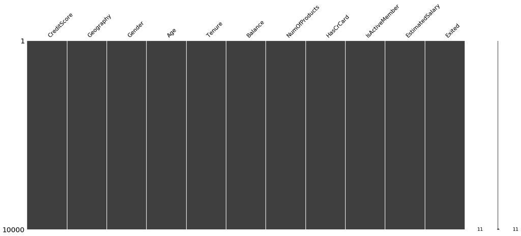

```python
# use the missingno to directly find if there is any missing data
import missingno as mn
mn.matrix(df)
```

From above we can see, there is no duplicated data.

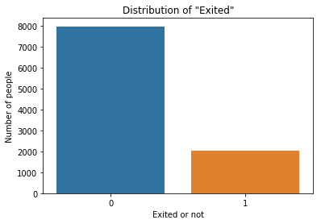

```python
# Set our target as the 'Exited'
target = df['Exited']
target_names='Exited'
y = target
vals = np.bincount(y)

params = [0, 1]
# plt.figure(figsize=(10,10))
fig, ax = plt.subplots(1, 1)

ax = sns.barplot(x=params, y=vals)
plt.title('Distribution of "Exited"')
plt.xlabel('Exited or not')
plt.ylabel('Number of people')
plt.show()
```

```python
from sklearn.preprocessing import LabelEncoder
from sklearn.preprocessing import StandardScaler
import numpy as np

# define objects that can encode each variable as integer
encoders = dict()
categorical_headers = ['Geography','Age','Gender','Tenure','NumOfProducts','HasCrCard','IsActiveMember']

# train all encoders (special case the target 'income')
for col in categorical_headers+['Exited']:
    if col=="Exited":
        tmp = LabelEncoder()
        df[col] = tmp.fit_transform(df[col])
    else:
        # integer encoded variables
        encoders[col] = LabelEncoder() # save the encoder
        df[col+'_int'] = encoders[col].fit_transform(df[col])

# scale the numeric, continuous variables
numeric_headers = ["CreditScore", "Balance","EstimatedSalary"]

for col in numeric_headers:
    df[col] = df[col].astype(np.float)

    ss = StandardScaler()
    df[col] = ss.fit_transform(df[col].values.reshape(-1, 1))

df.head()
```

|  | CreditScore | Geography | Gender | Age | Tenure | Balance | NumOfProducts | HasCrCard | IsActiveMember | EstimatedSalary | Exited | Geography_int | Age_int | Gender_int | Tenure_int | NumOfProducts_int | HasCrCard_int | IsActiveMember_int |
| --- | --- | --- | --- | --- | --- | --- | --- | --- | --- | --- | --- | --- | --- | --- | --- | --- | --- | --- |
| 0 | -0.326221 | France | Female | adult | 2 | -1.225848 | 1 | 1 | 1 | 0.021886 | 1 | 0 | 0 | 0 | 3 | 0 | 1 | 1 |
| 1 | -0.440036 | Spain | Female | adult | 1 | 0.117350 | 1 | 0 | 1 | 0.216534 | 0 | 2 | 0 | 0 | 1 | 0 | 0 | 1 |
| 2 | -1.536794 | France | Female | adult | 8 | 1.333053 | 3 | 1 | 0 | 0.240687 | 1 | 0 | 0 | 0 | 9 | 2 | 1 | 0 |
| 3 | 0.501521 | France | Female | adult | 1 | -1.225848 | 2 | 0 | 0 | -0.108918 | 0 | 0 | 0 | 0 | 1 | 1 | 0 | 0 |
| 4 | 2.063884 | Spain | Female | adult | 2 | 0.785728 | 1 | 1 | 1 | -0.365276 | 0 | 2 | 0 | 0 | 3 | 0 | 1 | 1 |

```python
# let's start as simply as possible, without any feature preprocessing
categorical_headers_ints = [x+'_int' for x in categorical_headers]
feature_columns = categorical_headers_ints+numeric_headers
print(feature_columns)
```

```
['Geography_int', 'Age_int', 'Gender_int', 'Tenure_int', 'NumOfProducts_int', 'HasCrCard_int', 'IsActiveMember_int', 'CreditScore', 'Balance', 'EstimatedSalary']
```

Here, we encode each categorical variable as integer and scale the numeric data using StandardScaler()

```python
from sklearn.model_selection import train_test_split
X_df_train, X_df_test = train_test_split(df, test_size=0.2, random_state=10, stratify=df['Exited'])
```

```python
y_train = X_df_train['Exited'].values.astype(np.int)
y_test = X_df_test['Exited'].values.astype(np.int)
```

```python
X_train_num =  X_df_train[numeric_headers].values
X_test_num = X_df_test[numeric_headers].values
```

Here we first split our dataset into 80% training data and 20% testing data for creating our wide and deep model. We we perform k-fold validation, we then use 10-fold cross validation.

## 1.2 Identifying Cross-Product Features

#### [10 points] Identify groups of features in your data that should be combined into cross-product features. Provide justification for why these features should be crossed (or why some features should not be crossed).

1. {Geography,NumOfProducts}: We think that 'Geography' and 'NumberOfProducts' should be crossed. For a specific area or country, the number of products of customers in a bank is related to the economic in that country. For instance, if a country's economic develops very well, the average fortune for the citizens is likely to be high. So, they may have extra money for various products in the bank other than the basic needs for daily life. The bank will also try to introduce more products for them. If a country is suffering from poor economic, and people are losing their jobs. It is very unlikely that they will have energy or money to buy many products in the bank.
1. {Gender,NumberOfProducts}: Actually, this is a interesting cross-product feature. From our usual point of view, we think that men are more likely interested in the products of the bank. Women have less interest for the products, and they may be harder to persuaded than men. Many believe that financial products are “gender-neutral” since they are open to both men and women. What financial institutions often don’t realize is that “neutral” products were often designed with men’s needs in mind — and unintentionally put women off. The reverse is not true, however: when products are created with women’s specific needs in mind, the data proves that men are just as or even more interested.
1. {Age,NumberOfProducts}:

[figure not shown]

From the above plot, we see that younger consumers primarily concerned with saving. But even among 18 to 35 year olds, behaviors are already changing. Older people from 18 to 35 year old show less concern with saving. By age 30, many people are on an established career path and their financial concerns are already beginning to shift. From 35 on up, you see people showing increased concern with protecting their assets. So, it is most likely that the number of products for customers in a bank will be affected by their age.

1. {HasCrCard,IsActiveMember}: We think that thses two features shoule be crossed. Since credit card is widely used in our daily life, many of the services and products from the bank are related with the credit card. If a customer has a credit card, he/she is most likely to use it. Then many customers would pay off the credit card bill monthly. Otherwise, if a customer does not have a credit card, he/she most likely does not go to the bank or use the bank's services regularly.
1. {HasCrCard,IsActiveMember,NumberOfProducts}: Like we discussed in 4, many products and services of the bank are related with the credit card. So, the NumberOfProducts should be crossed with the other two features.

## 1.3 Evaluation Criteria

#### [10 points] Choose and explain what metric(s) you will use to evaluate your algorithm’s performance. You should give a detailed argument for why this (these) metric(s) are appropriate on your data. That is, why is the metric appropriate for the task (e.g., in terms of the business case for the task). Please note: rarely is accuracy the best evaluation metric to use. Think deeply about an appropriate measure of performance.

For this lab, we will use recall score to evaluate our model. As you can see from the distribution of the target feature 'Exited', the number of instances for leaving and not leaving are not even, which indicate that using accuracy is not appropriate on our model. In this model, we are predicting a customer is whether leaving or not for a bank, the bank will take some action,such as new services, especially against those who are leaving according to our prediction to retain them. If our model predicts lots of people who are actually leaving into not leaving, then the bank will not take actions against them according to our prediction, which will most likely lose all of them. This is a great loss and the bank want the right prediction from us, they want to retain as much people as possible. So, we need to make sure the recall score of this model to be relatively high. On the other hand, if we predict lots of people who are actually not leaving into leaving, which means the precision score is low. The bank will take actions against them, which most likely make them happier and stay at the bank longer. There is hardly negative effect for the bank by doing that. So, we do not care much about the precision score, and we use the recall score to evaluate our model to get a good model for the bank.

## 1.4 Dividing Data

#### [10 points] Choose the method you will use for dividing your data into training and testing (i.e., are you using Stratified 10-fold cross validation? Shuffle splits? Why?). Explain why your chosen method is appropriate or use more than one method as appropriate. Argue why your cross validation method is a realistic mirroring of how an algorithm would be used in practice.

# 2. Modeling (50 points total)

## 2.1 Wide and Deep Networks Modeling

#### [20 points] Create several combined wide and deep networks to classify your data using Keras. Visualize the performance of the network on the training data and validation data in the same plot versus the training iterations. Note: use the "history" return parameter that is part of Keras "fit" function to easily access this data.

### 2.1.1 First Wide Deep Network (['Geography','NumOfProducts'] and ['HasCrCard','IsActiveMember'])

```python
from sklearn import metrics as mt
import keras

keras.__version__
```

```
'2.2.4'
```

```python
# from keras.models import Sequential
from keras.layers import Dense, Activation, Input
from keras.layers import Embedding, Flatten, concatenate
from keras.models import Model
```

```python
cross_columns = [['Geography','NumOfProducts'],
                 ['HasCrCard','IsActiveMember']]

# we need to create separate lists for each branch
embed_branches = []
X_ints_train = []
X_ints_test = []
all_inputs = []
all_wide_branch_outputs = []

for cols in cross_columns:
    # encode crossed columns as ints for the embedding
    enc = LabelEncoder()

    # create crossed labels
    X_crossed_train = X_df_train[cols].apply(lambda x: '_'.join(x), axis=1)
    X_crossed_test = X_df_test[cols].apply(lambda x: '_'.join(x), axis=1)

    enc.fit(np.hstack((X_crossed_train.values,  X_crossed_test.values)))
    X_crossed_train = enc.transform(X_crossed_train)
    X_crossed_test = enc.transform(X_crossed_test)
    X_ints_train.append(X_crossed_train)
    X_ints_test.append(X_crossed_test)

    # get the number of categories
    N = max(X_ints_train[-1]+1) # same as the max(df_train[col])

    # create embedding branch from the number of categories
    inputs = Input(shape=(1,),dtype='int32', name = '_'.join(cols))
    all_inputs.append(inputs)
    x = Embedding(input_dim=N,
                  output_dim=int(np.sqrt(N)),
                  input_length=1, name = '_'.join(cols)+'_embed')(inputs)
    x = Flatten()(x)
    all_wide_branch_outputs.append(x)

# merge the branches together
wide_branch = concatenate(all_wide_branch_outputs, name='wide_concat')
wide_branch = Dense(units=1,activation='sigmoid',name='wide_combined')(wide_branch)

# reset this input branch
all_deep_branch_outputs = []
# add in the embeddings
for col in categorical_headers_ints:
    # encode as ints for the embedding
    X_ints_train.append(X_df_train[col].values)
    X_ints_test.append(X_df_test[col].values)

    # get the number of categories
    N = max(X_ints_train[-1]+1) # same as the max(df_train[col])

    # create embedding branch from the number of categories
    inputs = Input(shape=(1,),dtype='int32', name=col)
    all_inputs.append(inputs)
    x = Embedding(input_dim=N,
                  output_dim=int(np.sqrt(N)),
                  input_length=1, name=col+'_embed')(inputs)
    x = Flatten()(x)
    all_deep_branch_outputs.append(x)

# also get a dense branch of the numeric features
all_inputs.append(Input(shape=(X_train_num.shape[1],),
                        sparse=False,
                        name='numeric_data'))

x = Dense(units=20, activation='relu',name='numeric_1')(all_inputs[-1])
all_deep_branch_outputs.append( x )

# merge the deep branches together
deep_branch = concatenate(all_deep_branch_outputs,name='concat_embeds')
deep_branch = Dense(units=50,activation='relu', name='deep1')(deep_branch)
deep_branch = Dense(units=25,activation='relu', name='deep2')(deep_branch)
deep_branch = Dense(units=10,activation='relu', name='deep3')(deep_branch)

final_branch = concatenate([wide_branch, deep_branch],name='concat_deep_wide')
final_branch = Dense(units=1,activation='sigmoid',name='combined')(final_branch)

model = Model(inputs=all_inputs, outputs=final_branch)
```

```python
model.summary()
```

```
__________________________________________________________________________________________________
Layer (type)                    Output Shape         Param #     Connected to
==================================================================================================
Geography_int (InputLayer)      (None, 1)            0
__________________________________________________________________________________________________
Age_int (InputLayer)            (None, 1)            0
__________________________________________________________________________________________________
Gender_int (InputLayer)         (None, 1)            0
__________________________________________________________________________________________________
Tenure_int (InputLayer)         (None, 1)            0
__________________________________________________________________________________________________
NumOfProducts_int (InputLayer)  (None, 1)            0
__________________________________________________________________________________________________
HasCrCard_int (InputLayer)      (None, 1)            0
__________________________________________________________________________________________________
IsActiveMember_int (InputLayer) (None, 1)            0
__________________________________________________________________________________________________
Geography_int_embed (Embedding) (None, 1, 1)         3           Geography_int[0][0]
__________________________________________________________________________________________________
Age_int_embed (Embedding)       (None, 1, 2)         8           Age_int[0][0]
__________________________________________________________________________________________________
Gender_int_embed (Embedding)    (None, 1, 1)         2           Gender_int[0][0]
__________________________________________________________________________________________________
Tenure_int_embed (Embedding)    (None, 1, 3)         33          Tenure_int[0][0]
__________________________________________________________________________________________________
NumOfProducts_int_embed (Embedd (None, 1, 2)         8           NumOfProducts_int[0][0]
__________________________________________________________________________________________________
HasCrCard_int_embed (Embedding) (None, 1, 1)         2           HasCrCard_int[0][0]
__________________________________________________________________________________________________
IsActiveMember_int_embed (Embed (None, 1, 1)         2           IsActiveMember_int[0][0]
__________________________________________________________________________________________________
numeric_data (InputLayer)       (None, 3)            0
__________________________________________________________________________________________________
Geography_NumOfProducts (InputL (None, 1)            0
__________________________________________________________________________________________________
HasCrCard_IsActiveMember (Input (None, 1)            0
__________________________________________________________________________________________________
flatten_140 (Flatten)           (None, 1)            0           Geography_int_embed[0][0]
__________________________________________________________________________________________________
flatten_141 (Flatten)           (None, 2)            0           Age_int_embed[0][0]
```

[output cut: 35 more lines]

```
deep2 (Dense)                   (None, 25)           1275        deep1[0][0]
__________________________________________________________________________________________________
wide_combined (Dense)           (None, 1)            6           wide_concat[0][0]
__________________________________________________________________________________________________
deep3 (Dense)                   (None, 10)           260         deep2[0][0]
__________________________________________________________________________________________________
concat_deep_wide (Concatenate)  (None, 11)           0           wide_combined[0][0]
                                                                 deep3[0][0]
__________________________________________________________________________________________________
combined (Dense)                (None, 1)            12          concat_deep_wide[0][0]
==================================================================================================
Total params: 3,335
Trainable params: 3,335
Non-trainable params: 0
__________________________________________________________________________________________________
```

```python
from IPython.display import SVG
from keras.utils.vis_utils import model_to_dot

# you will need to install pydot properly on your machine to get this running
SVG(model_to_dot(model).create(prog='dot', format='svg'))
```

[figure not shown]

For our first model, we have 3 layers and we combined 'Geography' and 'NumOfProducts' into a cross-product feature and we also combined 'HasCrCard' and 'IsActiveMember' into a cross-product feature like we talked about in section 1.2. Then we used those cross-product features to create our wide network. After embedding and flatten, we combined our wide network with our deep network and created our final wide and deep network. We summarized and visualized our model above.

```python
from keras import backend as K
def Precision(y_true, y_pred):
    """Precision"""
    tp= K.sum(K.round(K.clip(y_true * y_pred, 0, 1)))  # true positives
    pp= K.sum(K.round(K.clip(y_pred, 0, 1))) # predicted positives
    precision = tp/ (pp+ K.epsilon())
    return precision

def Recall(y_true, y_pred):
    """Recall"""
    tp = K.sum(K.round(K.clip(y_true * y_pred, 0, 1))) # true positives
    pp = K.sum(K.round(K.clip(y_true, 0, 1))) # possible positives
    recall = tp / (pp + K.epsilon())
    return recall

def F1(y_true, y_pred):
    """F1-score"""
    precision = Precision(y_true, y_pred)
    recall = Recall(y_true, y_pred)
    f1 = 2 * ((precision * recall) / (precision + recall + K.epsilon()))
    return f1
```

Because Keras doesn't provide recall metrics, we define Recall, Precision and F1 evaluation metrics here. For our model, we only use Recall evaluation metric.

```python
model.compile(optimizer='adagrad',
              loss='mean_squared_error',
              metrics=[Recall])

# lets also add the history variable to see how we are doing
# and lets add a validation set to keep track of our progress
history = model.fit(X_ints_train+ [X_train_num],
                    y_train,
                    epochs=20,
                    batch_size=32,
                    verbose=1,
                    validation_data = (X_ints_test + [X_test_num], y_test))
```

```
Train on 8000 samples, validate on 2000 samples
```

```python
yhat = np.round(model.predict(X_ints_test + [X_test_num]))
print(mt.confusion_matrix(y_test,yhat), mt.recall_score(y_test,yhat))
```

```
[[1537   56]
 [ 256  151]] 0.371007371007371
```

Then we fit our model using 20 epochs, batch size 32, using training data to train the model and test data to validate model. Here we use 80% training data and 20% test data. Later when we conduct cross validation, we then split our data using 10-fold cross validation.  
As we can see above, the Recall score is not good, which is only 37%.

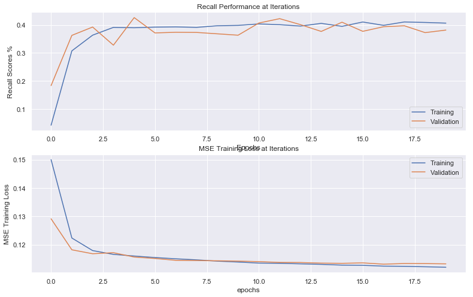

```python
%matplotlib inline

plt.figure(figsize=(13,8))
plt.subplot(2,1,1)
plt.ylabel('Recall Scores %')
plt.xlabel('Epochs')
plt.title('Recall Performance at Iterations')
plt.plot(history.history['Recall'], label='Training')
plt.plot(history.history['val_Recall'], label='Validation')
plt.legend()

plt.subplot(2,1,2)
plt.ylabel('MSE Training Loss')
plt.xlabel('epochs')
plt.title('MSE Training Loss at Iterations')
plt.plot(history.history['loss'], label='Training')
plt.plot(history.history['val_loss'], label='Validation')
plt.legend()
```

Then we visualize the Recall Score VS Number of epochs and Loss VS Number of epochs. From above, it seems that our model converges eventually, but our model overfit a little. In the second model, we will change our cross-product features. Let's see how next model performs.

### 2.1.2 Second Wide Deep Network (['Geography','NumOfProducts'], ['Gender','NumOfProducts'], ['Age','NumOfProducts'] and ['HasCrCard', 'IsActiveMember', 'NumOfProducts'])

```python
# 'workclass','education','marital_status',
# 'occupation','relationship','race',
# 'sex','country'

cross_columns = [['Geography','NumOfProducts'],
                 ['Gender','NumOfProducts'],
                 ['Age','NumOfProducts'],
                 ['HasCrCard', 'IsActiveMember', 'NumOfProducts']]

#'workclass','education','marital_status','occupation','relationship','race','sex','country'

# we need to create separate lists for each branch
embed_branches = []
X_ints_train = []
X_ints_test = []
all_inputs = []
all_wide_branch_outputs = []

for cols in cross_columns:
    # encode crossed columns as ints for the embedding
    enc = LabelEncoder()

    # create crossed labels
    X_crossed_train = X_df_train[cols].apply(lambda x: '_'.join(x), axis=1)
    X_crossed_test = X_df_test[cols].apply(lambda x: '_'.join(x), axis=1)

    enc.fit(np.hstack((X_crossed_train.values,  X_crossed_test.values)))
    X_crossed_train = enc.transform(X_crossed_train)
    X_crossed_test = enc.transform(X_crossed_test)
    X_ints_train.append(X_crossed_train)
    X_ints_test.append(X_crossed_test)

    # get the number of categories
    N = max(X_ints_train[-1]+1) # same as the max(df_train[col])

    # create embedding branch from the number of categories
    inputs = Input(shape=(1,),dtype='int32', name = '_'.join(cols))
    all_inputs.append(inputs)
    x = Embedding(input_dim=N,
                  output_dim=int(np.sqrt(N)),
                  input_length=1, name = '_'.join(cols)+'_embed')(inputs)
    x = Flatten()(x)
    all_wide_branch_outputs.append(x)

# merge the branches together
wide_branch = concatenate(all_wide_branch_outputs, name='wide_concat')
wide_branch = Dense(units=1,activation='sigmoid',name='wide_combined')(wide_branch)

# reset this input branch
all_deep_branch_outputs = []
# add in the embeddings
for col in categorical_headers_ints:
    # encode as ints for the embedding
    X_ints_train.append(X_df_train[col].values)
    X_ints_test.append(X_df_test[col].values)

    # get the number of categories
    N = max(X_ints_train[-1]+1) # same as the max(df_train[col])

    # create embedding branch from the number of categories
    inputs = Input(shape=(1,),dtype='int32', name=col)
    all_inputs.append(inputs)
    x = Embedding(input_dim=N,
                  output_dim=int(np.sqrt(N)),
                  input_length=1, name=col+'_embed')(inputs)
    x = Flatten()(x)
    all_deep_branch_outputs.append(x)

# also get a dense branch of the numeric features
all_inputs.append(Input(shape=(X_train_num.shape[1],),
                        sparse=False,
                        name='numeric_data'))

x = Dense(units=20, activation='relu',name='numeric_1')(all_inputs[-1])
all_deep_branch_outputs.append( x )

# merge the deep branches together
deep_branch = concatenate(all_deep_branch_outputs,name='concat_embeds')
deep_branch = Dense(units=50,activation='relu', name='deep1')(deep_branch)
deep_branch = Dense(units=25,activation='relu', name='deep2')(deep_branch)
deep_branch = Dense(units=10,activation='relu', name='deep3')(deep_branch)

final_branch = concatenate([wide_branch, deep_branch],name='concat_deep_wide')
final_branch = Dense(units=1,activation='sigmoid',name='combined')(final_branch)

model = Model(inputs=all_inputs, outputs=final_branch)
```

```python
model.summary()
```

```
__________________________________________________________________________________________________
Layer (type)                    Output Shape         Param #     Connected to
==================================================================================================
Geography_int (InputLayer)      (None, 1)            0
__________________________________________________________________________________________________
Age_int (InputLayer)            (None, 1)            0
__________________________________________________________________________________________________
Gender_int (InputLayer)         (None, 1)            0
__________________________________________________________________________________________________
Tenure_int (InputLayer)         (None, 1)            0
__________________________________________________________________________________________________
NumOfProducts_int (InputLayer)  (None, 1)            0
__________________________________________________________________________________________________
HasCrCard_int (InputLayer)      (None, 1)            0
__________________________________________________________________________________________________
IsActiveMember_int (InputLayer) (None, 1)            0
__________________________________________________________________________________________________
Geography_int_embed (Embedding) (None, 1, 1)         3           Geography_int[0][0]
__________________________________________________________________________________________________
Age_int_embed (Embedding)       (None, 1, 2)         8           Age_int[0][0]
__________________________________________________________________________________________________
Gender_int_embed (Embedding)    (None, 1, 1)         2           Gender_int[0][0]
__________________________________________________________________________________________________
Tenure_int_embed (Embedding)    (None, 1, 3)         33          Tenure_int[0][0]
__________________________________________________________________________________________________
NumOfProducts_int_embed (Embedd (None, 1, 2)         8           NumOfProducts_int[0][0]
__________________________________________________________________________________________________
HasCrCard_int_embed (Embedding) (None, 1, 1)         2           HasCrCard_int[0][0]
__________________________________________________________________________________________________
IsActiveMember_int_embed (Embed (None, 1, 1)         2           IsActiveMember_int[0][0]
__________________________________________________________________________________________________
numeric_data (InputLayer)       (None, 3)            0
__________________________________________________________________________________________________
Geography_NumOfProducts (InputL (None, 1)            0
__________________________________________________________________________________________________
Gender_NumOfProducts (InputLaye (None, 1)            0
__________________________________________________________________________________________________
Age_NumOfProducts (InputLayer)  (None, 1)            0
__________________________________________________________________________________________________
HasCrCard_IsActiveMember_NumOfP (None, 1)            0
```

[output cut: 49 more lines]

```
deep2 (Dense)                   (None, 25)           1275        deep1[0][0]
__________________________________________________________________________________________________
wide_combined (Dense)           (None, 1)            13          wide_concat[0][0]
__________________________________________________________________________________________________
deep3 (Dense)                   (None, 10)           260         deep2[0][0]
__________________________________________________________________________________________________
concat_deep_wide (Concatenate)  (None, 11)           0           wide_combined[0][0]
                                                                 deep3[0][0]
__________________________________________________________________________________________________
combined (Dense)                (None, 1)            12          concat_deep_wide[0][0]
==================================================================================================
Total params: 3,456
Trainable params: 3,456
Non-trainable params: 0
__________________________________________________________________________________________________
```

```python
# you will need to install pydot properly on your machine to get this running
SVG(model_to_dot(model).create(prog='dot', format='svg'))
```

[figure not shown]

For our second model, we still have 3 layers but we used all cross-product features we talked about in section 1.2, which are ['Geography','NumOfProducts'], ['Gender','NumOfProducts'], ['Age','NumOfProducts'] and ['HasCrCard', 'IsActiveMember', 'NumOfProducts']. Then we used those cross-product features to create our wide network. After embedding and flatten, we combined our wide network with our deep network and created our final wide and deep network. We summarized and visualized our second model above.

```python
model.compile(optimizer='adagrad',
              loss='mean_squared_error',
              metrics=[Recall])

# lets also add the history variable to see how we are doing
# and lets add a validation set to keep track of our progress
history = model.fit(X_ints_train+ [X_train_num],
                    y_train,
                    epochs=20,
                    batch_size=32,
                    verbose=1,
                    validation_data = (X_ints_test + [X_test_num], y_test))
```

```
Train on 8000 samples, validate on 2000 samples
```

```python
yhat = np.round(model.predict(X_ints_test + [X_test_num]))
print(mt.confusion_matrix(y_test,yhat), mt.recall_score(y_test,yhat))
```

```
[[1526   67]
 [ 243  164]] 0.40294840294840295
```

Then we fit our second model using 20 epochs, batch size 32, using training data to train the model and test data to validate model. Here we use 80% training data and 20% test data. Later when we conduct cross validation, we then split our data using 10-fold cross validation. As we can see above, the Recall score is still not good, which is 40% that is similar to the first model even though it improves from 37% to 40%.

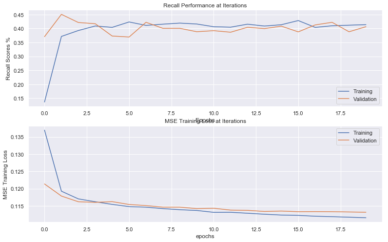

```python
%matplotlib inline

plt.figure(figsize=(13,8))
plt.subplot(2,1,1)
plt.ylabel('Recall Scores %')
plt.xlabel('Epochs')
plt.title('Recall Performance at Iterations')
plt.plot(history.history['Recall'], label='Training')
plt.plot(history.history['val_Recall'], label='Validation')
plt.legend()

plt.subplot(2,1,2)
plt.ylabel('MSE Training Loss')
plt.xlabel('epochs')
plt.title('MSE Training Loss at Iterations')
plt.plot(history.history['loss'], label='Training')
plt.plot(history.history['val_loss'], label='Validation')
plt.legend()
```

Then we visualize the Recall Score VS Number of epochs and Loss VS Number of epochs. From above, we can see our second model converages eventually but the overfitting problem still exists even though the recall scores improves a little. But overall, neither of the two models performs well.

## 2.2 Investigating Generalization Performance

#### [20 points] Investigate generalization performance by altering the number of layers in the deep branch of the network. Try at least two different number of layers. Use the method of cross validation and evaluation metric that you argued for at the beginning of the lab to select the number of layers that performs superiorly.

```python
# 'workclass','education','marital_status',
# 'occupation','relationship','race',
# 'sex','country'
def wide_deep_network(layers=[50, 25, 10]):
    cross_columns = [['Geography','NumOfProducts'],
                     ['Gender','NumOfProducts'],
                     ['Age','NumOfProducts'],
                     ['HasCrCard', 'IsActiveMember', 'NumOfProducts']]

    #'workclass','education','marital_status','occupation','relationship','race','sex','country'

    # we need to create separate lists for each branch
    embed_branches = []
    X_ints_train = []
    X_ints_test = []
    all_inputs = []
    all_wide_branch_outputs = []

    for cols in cross_columns:
        # encode crossed columns as ints for the embedding
        enc = LabelEncoder()

        # create crossed labels
        X_crossed_train = X_df_train[cols].apply(lambda x: '_'.join(x), axis=1)
        X_crossed_test = X_df_test[cols].apply(lambda x: '_'.join(x), axis=1)

        enc.fit(np.hstack((X_crossed_train.values,  X_crossed_test.values)))
        X_crossed_train = enc.transform(X_crossed_train)
        X_crossed_test = enc.transform(X_crossed_test)
        X_ints_train.append(X_crossed_train)
        X_ints_test.append(X_crossed_test)

        # get the number of categories
        N = max(X_ints_train[-1]+1) # same as the max(df_train[col])

        # create embedding branch from the number of categories
        inputs = Input(shape=(1,),dtype='int32', name = '_'.join(cols))
        all_inputs.append(inputs)
        x = Embedding(input_dim=N,
                      output_dim=int(np.sqrt(N)),
                      input_length=1, name = '_'.join(cols)+'_embed')(inputs)
        x = Flatten()(x)
        all_wide_branch_outputs.append(x)

    # merge the branches together
    wide_branch = concatenate(all_wide_branch_outputs, name='wide_concat')
    wide_branch = Dense(units=1,activation='sigmoid',name='wide_combined')(wide_branch)

    # reset this input branch
    all_deep_branch_outputs = []
    # add in the embeddings
    for col in categorical_headers_ints:
        # encode as ints for the embedding
        X_ints_train.append(X_df_train[col].values)
        X_ints_test.append(X_df_test[col].values)

        # get the number of categories
        N = max(X_ints_train[-1]+1) # same as the max(df_train[col])

        # create embedding branch from the number of categories
        inputs = Input(shape=(1,),dtype='int32', name=col)
        all_inputs.append(inputs)
        x = Embedding(input_dim=N,
                      output_dim=int(np.sqrt(N)),
                      input_length=1, name=col+'_embed')(inputs)
        x = Flatten()(x)
        all_deep_branch_outputs.append(x)

    # also get a dense branch of the numeric features
    all_inputs.append(Input(shape=(X_train_num.shape[1],),
                            sparse=False,
                            name='numeric_data'))

    x = Dense(units=20, activation='relu',name='numeric_1')(all_inputs[-1])
    all_deep_branch_outputs.append( x )

    # merge the deep branches together
    deep_branch = concatenate(all_deep_branch_outputs,name='concat_embeds')
    for idx, layer in enumerate(layers):
        deep_branch = Dense(units=layer,activation='relu', name='deep{}'.format(str(idx+1)))(deep_branch)

    final_branch = concatenate([wide_branch, deep_branch],name='concat_deep_wide')
    final_branch = Dense(units=1,activation='sigmoid',name='combined')(final_branch)

    model = Model(inputs=all_inputs, outputs=final_branch)
    model.compile(optimizer='adagrad',
                  loss='mean_squared_error',
                  metrics=[Recall])

    X_train = X_ints_train+ [X_train_num]
    X_test = X_ints_test + [X_test_num]
    return model, X_train, X_test
```

In order to add more layers into deep networks, we put our model into a function, we add layers as a parameter of this function. For cross-product features, we used cross-product features of model2.

```python
import numpy as np
from sklearn.model_selection import StratifiedKFold

layer_range = [[50, 25, 10], [100, 50, 25, 10], [200, 100, 50, 25, 10]]

scores = []
for layer in layer_range:
    model, X_train, X_test = wide_deep_network(layers=layer)
    X_train_num = X_train[-1]
    X_train_ints = np.array(X_train[:-1])
    X_train_full = np.hstack((X_train_ints.T, X_train_num))
    score_temp = []
    kFold = StratifiedKFold(n_splits=10, random_state=1).split(X_train_full, y_train)
    for k, (train, test) in enumerate(kFold):
        model.fit(X_train_full[train][:, :-3].T.tolist() + [X_train_full[train][:, -3:]],
              y_train[train], epochs=20, batch_size=32, verbose=0)
        yhat = np.round(model.predict(X_train_full[test][:, :-3].T.tolist() + [X_train_full[test][:, -3:]]))
        score = mt.recall_score(y_train[test],yhat)
        score_temp += [score]
    scores.append(score_temp)
```

Then we used 10-fold cross validation to determine the general performance of different number of layers using recall score. In order to split the dataset using 10-fold, we first convert X_ints_train and X_train_num to an full numpy array. And when we put data into the wide and deep network, we then convert that full numpy array back to the original form. We used 3 different number of layers, 50, 25, 10], [100, 50, 25, 10] and [200, 100, 50, 25, 10]. After we get the result from each fold, we store the result into an list.

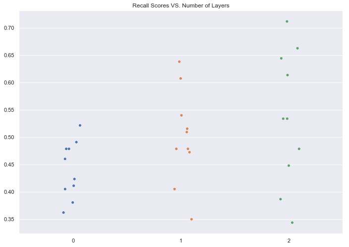

```python
import seaborn as sns
sns.set(rc={'figure.figsize':(11.7,8.27)})
sns.stripplot(data=scores, jitter=True).set_title('Recall Scores VS. Number of Layers')
```

We plot a stripplot for visualizing the performance of different number of layers in deep network. Index 0 represents 3 layers, index 1 represents 4 layers and index2 represents 5 layers. As we can see from above, 5 layers produce better recall score than 3 layers and 4 layers averagely.

```python
mean_recall_scores = []
for score in scores:
    mean = np.mean(score)
    mean_recall_scores.append(mean)
```

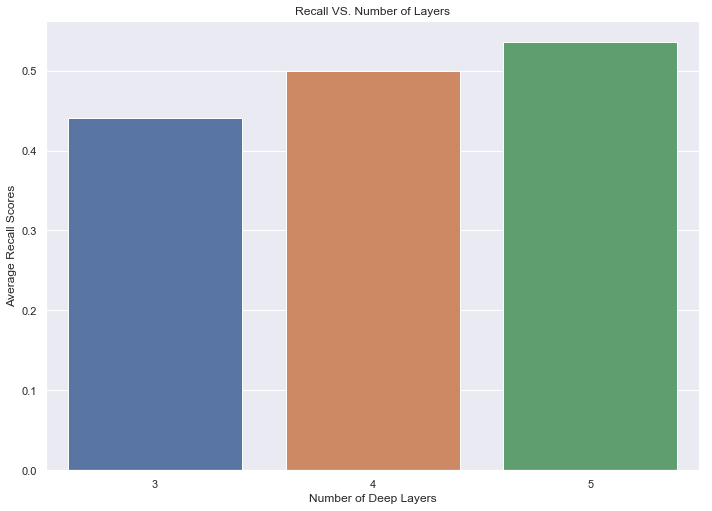

```python
import matplotlib.pyplot as plt
params = [3, 4, 5]
# plt.figure(figsize=(10,10))
fig, ax = plt.subplots(1, 1)

ax = sns.barplot(x=params, y=mean_recall_scores)
plt.title('Recall VS. Number of Layers')
plt.xlabel('Number of Deep Layers')
plt.ylabel('Average Recall Scores')
plt.show()
```

We also calculate the average recall score of each model, and polt a barplot to visualize the average recall scores. As we can see above, 5 layers have the best recall score averagely. So we will use 5 layers for comparing Wide Deep Network with MLP in next section.

## 2.3 Comparasion Between MLP and Wide Deep Network

#### [10 points] Compare the performance of your best wide and deep network to a standard multi-layer perceptron (MLP). For classification tasks, use the receiver operating characteristic and area under the curve. For regression tasks, use Bland-Altman plots and residual variance calculations. Use proper statistical method to compare the performance of different models.

```python
X_train1 = X_df_train[feature_columns].values
X_test1 = X_df_test[feature_columns].values
y_train1 = X_df_train['Exited'].values.astype(np.int)
y_test1 = X_df_test['Exited'].values.astype(np.int)
```

```python
from keras.models import Sequential
from keras.layers.core import Dense, Dropout, Activation
from keras.optimizers import SGD
from sklearn.metrics import roc_curve, auc

# This returns a tensor
inputs = Input(shape=(X_train1.shape[1],))

# a layer instance is callable on a tensor, and returns a tensor
x = Dense(units=200, activation='relu')(inputs)
x = Dense(units=100, activation='tanh')(x)
x = Dense(units=50, activation='tanh')(x)
x = Dense(units=25, activation='tanh')(x)
x = Dense(units=10, activation='tanh')(x)
predictions = Dense(1,activation='sigmoid')(x)

# This creates a model that includes
# the Input layer and three Dense layers
model1 = Model(inputs=inputs, outputs=predictions)

sgd = SGD(lr=0.1, decay=1e-6, momentum=0.9, nesterov=True)
model1.compile(loss='mean_squared_error', optimizer=sgd, metrics=[Recall])
```

First, we implement a multi layer perceptron as model1 which have 5 layers.

```python
# 'workclass','education','marital_status',
# 'occupation','relationship','race',
# 'sex','country'
def wide_deep_network1(layers=[50, 25, 10]):
    cross_columns = [['Geography','NumOfProducts'],
                     ['HasCrCard','IsActiveMember']]

    #'workclass','education','marital_status','occupation','relationship','race','sex','country'

    # we need to create separate lists for each branch
    embed_branches = []
    X_ints_train = []
    X_ints_test = []
    all_inputs = []
    all_wide_branch_outputs = []

    for cols in cross_columns:
        # encode crossed columns as ints for the embedding
        enc = LabelEncoder()

        # create crossed labels
        X_crossed_train = X_df_train[cols].apply(lambda x: '_'.join(x), axis=1)
        X_crossed_test = X_df_test[cols].apply(lambda x: '_'.join(x), axis=1)

        enc.fit(np.hstack((X_crossed_train.values,  X_crossed_test.values)))
        X_crossed_train = enc.transform(X_crossed_train)
        X_crossed_test = enc.transform(X_crossed_test)
        X_ints_train.append(X_crossed_train)
        X_ints_test.append(X_crossed_test)

        # get the number of categories
        N = max(X_ints_train[-1]+1) # same as the max(df_train[col])

        # create embedding branch from the number of categories
        inputs = Input(shape=(1,),dtype='int32', name = '_'.join(cols))
        all_inputs.append(inputs)
        x = Embedding(input_dim=N,
                      output_dim=int(np.sqrt(N)),
                      input_length=1, name = '_'.join(cols)+'_embed')(inputs)
        x = Flatten()(x)
        all_wide_branch_outputs.append(x)

    # merge the branches together
    wide_branch = concatenate(all_wide_branch_outputs, name='wide_concat')
    wide_branch = Dense(units=1,activation='sigmoid',name='wide_combined')(wide_branch)

    # reset this input branch
    all_deep_branch_outputs = []
    # add in the embeddings
    for col in categorical_headers_ints:
        # encode as ints for the embedding
        X_ints_train.append(X_df_train[col].values)
        X_ints_test.append(X_df_test[col].values)

        # get the number of categories
        N = max(X_ints_train[-1]+1) # same as the max(df_train[col])

        # create embedding branch from the number of categories
        inputs = Input(shape=(1,),dtype='int32', name=col)
        all_inputs.append(inputs)
        x = Embedding(input_dim=N,
                      output_dim=int(np.sqrt(N)),
                      input_length=1, name=col+'_embed')(inputs)
        x = Flatten()(x)
        all_deep_branch_outputs.append(x)

    # also get a dense branch of the numeric features
    all_inputs.append(Input(shape=(X_train_num.shape[1],),
                            sparse=False,
                            name='numeric_data'))

    x = Dense(units=20, activation='relu',name='numeric_1')(all_inputs[-1])
    all_deep_branch_outputs.append( x )

    # merge the deep branches together
    deep_branch = concatenate(all_deep_branch_outputs,name='concat_embeds')
    for idx, layer in enumerate(layers):
        deep_branch = Dense(units=layer,activation='relu', name='deep{}'.format(str(idx+1)))(deep_branch)

    final_branch = concatenate([wide_branch, deep_branch],name='concat_deep_wide')
    final_branch = Dense(units=1,activation='sigmoid',name='combined')(final_branch)

    model = Model(inputs=all_inputs, outputs=final_branch)
    model.compile(optimizer='adagrad',
                  loss='mean_squared_error',
                  metrics=[Recall])

    X_train = X_ints_train+ [X_train_num]
    X_test = X_ints_test + [X_test_num]
    return model, X_train, X_test
```

```python
model2, X_train2, X_test2 = wide_deep_network([200, 100, 50, 25, 10])
```

```python
# 'workclass','education','marital_status',
# 'occupation','relationship','race',
# 'sex','country'
def wide_deep_network2(layers=[50, 25, 10]):
    cross_columns = [['Geography','NumOfProducts'],
                     ['Gender','NumOfProducts'],
                     ['Age','NumOfProducts'],
                     ['HasCrCard', 'IsActiveMember', 'NumOfProducts']]

    #'workclass','education','marital_status','occupation','relationship','race','sex','country'

    # we need to create separate lists for each branch
    embed_branches = []
    X_ints_train = []
    X_ints_test = []
    all_inputs = []
    all_wide_branch_outputs = []

    for cols in cross_columns:
        # encode crossed columns as ints for the embedding
        enc = LabelEncoder()

        # create crossed labels
        X_crossed_train = X_df_train[cols].apply(lambda x: '_'.join(x), axis=1)
        X_crossed_test = X_df_test[cols].apply(lambda x: '_'.join(x), axis=1)

        enc.fit(np.hstack((X_crossed_train.values,  X_crossed_test.values)))
        X_crossed_train = enc.transform(X_crossed_train)
        X_crossed_test = enc.transform(X_crossed_test)
        X_ints_train.append(X_crossed_train)
        X_ints_test.append(X_crossed_test)

        # get the number of categories
        N = max(X_ints_train[-1]+1) # same as the max(df_train[col])

        # create embedding branch from the number of categories
        inputs = Input(shape=(1,),dtype='int32', name = '_'.join(cols))
        all_inputs.append(inputs)
        x = Embedding(input_dim=N,
                      output_dim=int(np.sqrt(N)),
                      input_length=1, name = '_'.join(cols)+'_embed')(inputs)
        x = Flatten()(x)
        all_wide_branch_outputs.append(x)

    # merge the branches together
    wide_branch = concatenate(all_wide_branch_outputs, name='wide_concat')
    wide_branch = Dense(units=1,activation='sigmoid',name='wide_combined')(wide_branch)

    # reset this input branch
    all_deep_branch_outputs = []
    # add in the embeddings
    for col in categorical_headers_ints:
        # encode as ints for the embedding
        X_ints_train.append(X_df_train[col].values)
        X_ints_test.append(X_df_test[col].values)

        # get the number of categories
        N = max(X_ints_train[-1]+1) # same as the max(df_train[col])

        # create embedding branch from the number of categories
        inputs = Input(shape=(1,),dtype='int32', name=col)
        all_inputs.append(inputs)
        x = Embedding(input_dim=N,
                      output_dim=int(np.sqrt(N)),
                      input_length=1, name=col+'_embed')(inputs)
        x = Flatten()(x)
        all_deep_branch_outputs.append(x)

    # also get a dense branch of the numeric features
    all_inputs.append(Input(shape=(X_train_num.shape[1],),
                            sparse=False,
                            name='numeric_data'))

    x = Dense(units=20, activation='relu',name='numeric_1')(all_inputs[-1])
    all_deep_branch_outputs.append( x )

    # merge the deep branches together
    deep_branch = concatenate(all_deep_branch_outputs,name='concat_embeds')
    for idx, layer in enumerate(layers):
        deep_branch = Dense(units=layer,activation='relu', name='deep{}'.format(str(idx+1)))(deep_branch)

    final_branch = concatenate([wide_branch, deep_branch],name='concat_deep_wide')
    final_branch = Dense(units=1,activation='sigmoid',name='combined')(final_branch)

    model = Model(inputs=all_inputs, outputs=final_branch)
    model.compile(optimizer='adagrad',
                  loss='mean_squared_error',
                  metrics=[Recall])

    X_train = X_ints_train+ [X_train_num]
    X_test = X_ints_test + [X_test_num]
    return model, X_train, X_test
```

```python
model3, X_train3, X_test3 = wide_deep_network2([200, 100, 50, 25, 10])
```

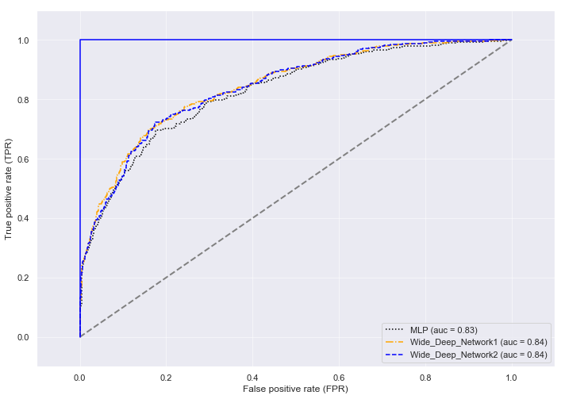

```python
from sklearn.metrics import roc_curve
from sklearn.metrics import auc
colors = ['black', 'orange', 'blue']
linestyles = [':', '-.', '--']
labels = ['MLP', 'Wide_Deep_Network1', 'Wide_Deep_Network2']
model1.fit(X_train1, y_train1, epochs=20, batch_size=32, verbose=0)
yhat_proba1 = model1.predict(X_test1)
model2, X_train2, X_test2 = wide_deep_network1([200, 100, 50, 25, 10])
model2.fit(X_train2, y_train, epochs=20, batch_size=32, verbose=0)
yhat_proba2 = model2.predict(X_test2)
model3, X_train3, X_test3 = wide_deep_network2([200, 100, 50, 25, 10])
model3.fit(X_train3, y_train, epochs=20, batch_size=32, verbose=0)
yhat_proba3 = model3.predict(X_test3)
score_compare = [(y_test1, yhat_proba1), (y_test, yhat_proba2), (y_test, yhat_proba3)]
for score_n, label, clr, ls in zip(score_compare, labels, colors, linestyles):
    fpr, tpr, thresholds = roc_curve(y_true=score_n[0], y_score=score_n[1])
    roc_auc = auc(x=fpr, y=tpr)
    plt.plot(fpr, tpr, color=clr, linestyle=ls, label='%s (auc = %0.2f)' % (label, roc_auc))
plt.legend(loc='lower right')
plt.plot([0, 1], [0, 1], linestyle='--', color='gray', linewidth=2)
plt.plot([0, 0, 1], [0, 1, 1], linestyle='-', color='blue', label='perfect performance')
plt.xlim([-0.1, 1.1])
plt.ylim([-0.1, 1.1])
plt.grid(alpha=0.5)
plt.xlabel('False positive rate (FPR)')
plt.ylabel('True positive rate (TPR)')
plt.show()
```

After we created three models(model1-MLP, model2-Wide Deep Network with 2 cross-products and model3-Wide Deep Network with 4 cross-products), we fit them with our dataset and plot ROC curves and auc results from the test set to check their general performance. As we can see in the resulting ROC, they are statistically similar with each other, so the performance of three models are similar with each other. But the two wide deep networks with cross-product features performs slightly better(ROC AUC=0.84) than other MLP.

# 3.Exceptional Work (10 points total)

#### 5000 students: You have free reign to provide additional analyses. One idea (required for 7000 level students): Capture the embedding weights from the deep network and (if needed) perform t-SNE dimensionality reduction on the output of these embedding layers (only if needed). That is, pass the observations into the network, save the embedded weights (called embeddings), and then perform dimensionality reduction in order to visualize results. Visualize and explain any clusters in the data.

```python
# 'workclass','education','marital_status',
# 'occupation','relationship','race',
# 'sex','country'

cross_columns = [['Geography','NumOfProducts'],
                 ['Gender','NumOfProducts'],
                 ['Age','NumOfProducts'],
                 ['HasCrCard', 'IsActiveMember', 'NumOfProducts']]

#'workclass','education','marital_status','occupation','relationship','race','sex','country'

# we need to create separate lists for each branch
embed_branches = []
X_ints_train = []
X_ints_test = []
all_inputs = []
all_wide_branch_outputs = []

for cols in cross_columns:
    # encode crossed columns as ints for the embedding
    enc = LabelEncoder()

    # create crossed labels
    X_crossed_train = X_df_train[cols].apply(lambda x: '_'.join(x), axis=1)
    X_crossed_test = X_df_test[cols].apply(lambda x: '_'.join(x), axis=1)

    enc.fit(np.hstack((X_crossed_train.values,  X_crossed_test.values)))
    X_crossed_train = enc.transform(X_crossed_train)
    X_crossed_test = enc.transform(X_crossed_test)
    X_ints_train.append(X_crossed_train)
    X_ints_test.append(X_crossed_test)

    # get the number of categories
    N = max(X_ints_train[-1]+1) # same as the max(df_train[col])

    # create embedding branch from the number of categories
    inputs = Input(shape=(1,),dtype='int32', name = '_'.join(cols))
    all_inputs.append(inputs)
    x = Embedding(input_dim=N,
                  output_dim=int(np.sqrt(N)),
                  input_length=1, name = '_'.join(cols)+'_embed')(inputs)
    x = Flatten()(x)
    all_wide_branch_outputs.append(x)

# merge the branches together
wide_branch = concatenate(all_wide_branch_outputs, name='wide_concat')
wide_branch = Dense(units=1,activation='sigmoid',name='wide_combined')(wide_branch)

# reset this input branch
all_deep_branch_outputs = []
# add in the embeddings
for col in categorical_headers_ints:
    # encode as ints for the embedding
    X_ints_train.append(X_df_train[col].values)
    X_ints_test.append(X_df_test[col].values)

    # get the number of categories
    N = max(X_ints_train[-1]+1) # same as the max(df_train[col])

    # create embedding branch from the number of categories
    inputs = Input(shape=(1,),dtype='int32', name=col)
    all_inputs.append(inputs)
    x = Embedding(input_dim=N,
                  output_dim=int(np.sqrt(N)),
                  input_length=1, name=col+'_embed')(inputs)
    x = Flatten()(x)
    all_deep_branch_outputs.append(x)

# also get a dense branch of the numeric features
all_inputs.append(Input(shape=(X_train_num.shape[1],),
                        sparse=False,
                        name='numeric_data'))

x = Dense(units=20, activation='relu',name='numeric_1')(all_inputs[-1])
all_deep_branch_outputs.append( x )

# merge the deep branches together
deep_branch = concatenate(all_deep_branch_outputs,name='concat_embeds')
deep_branch = Dense(units=50,activation='relu', name='deep1')(deep_branch)
deep_branch = Dense(units=25,activation='relu', name='deep2')(deep_branch)
deep_branch = Dense(units=10,activation='relu', name='deep3')(deep_branch)

final_branch = concatenate([wide_branch, deep_branch],name='concat_deep_wide')
final_branch = Dense(units=1,activation='sigmoid',name='combined')(final_branch)

model = Model(inputs=all_inputs, outputs=final_branch)
```

```python
model.compile(optimizer='adagrad',
              loss='mean_squared_error',
              metrics=[Recall])

# lets also add the history variable to see how we are doing
# and lets add a validation set to keep track of our progress
history = model.fit(X_ints_train+ [X_train_num],
                    y_train,
                    epochs=20,
                    batch_size=32,
                    verbose=0,
                    validation_data = (X_ints_test + [X_test_num], y_test))
```

```python
model.summary()
```

```
__________________________________________________________________________________________________
Layer (type)                    Output Shape         Param #     Connected to
==================================================================================================
Geography_int (InputLayer)      (None, 1)            0
__________________________________________________________________________________________________
Age_int (InputLayer)            (None, 1)            0
__________________________________________________________________________________________________
Gender_int (InputLayer)         (None, 1)            0
__________________________________________________________________________________________________
Tenure_int (InputLayer)         (None, 1)            0
__________________________________________________________________________________________________
NumOfProducts_int (InputLayer)  (None, 1)            0
__________________________________________________________________________________________________
HasCrCard_int (InputLayer)      (None, 1)            0
__________________________________________________________________________________________________
IsActiveMember_int (InputLayer) (None, 1)            0
__________________________________________________________________________________________________
Geography_int_embed (Embedding) (None, 1, 1)         3           Geography_int[0][0]
__________________________________________________________________________________________________
Age_int_embed (Embedding)       (None, 1, 2)         8           Age_int[0][0]
__________________________________________________________________________________________________
Gender_int_embed (Embedding)    (None, 1, 1)         2           Gender_int[0][0]
__________________________________________________________________________________________________
Tenure_int_embed (Embedding)    (None, 1, 3)         33          Tenure_int[0][0]
__________________________________________________________________________________________________
NumOfProducts_int_embed (Embedd (None, 1, 2)         8           NumOfProducts_int[0][0]
__________________________________________________________________________________________________
HasCrCard_int_embed (Embedding) (None, 1, 1)         2           HasCrCard_int[0][0]
__________________________________________________________________________________________________
IsActiveMember_int_embed (Embed (None, 1, 1)         2           IsActiveMember_int[0][0]
__________________________________________________________________________________________________
numeric_data (InputLayer)       (None, 3)            0
__________________________________________________________________________________________________
Geography_NumOfProducts (InputL (None, 1)            0
__________________________________________________________________________________________________
Gender_NumOfProducts (InputLaye (None, 1)            0
__________________________________________________________________________________________________
Age_NumOfProducts (InputLayer)  (None, 1)            0
__________________________________________________________________________________________________
HasCrCard_IsActiveMember_NumOfP (None, 1)            0
```

[output cut: 49 more lines]

```
deep2 (Dense)                   (None, 25)           1275        deep1[0][0]
__________________________________________________________________________________________________
wide_combined (Dense)           (None, 1)            13          wide_concat[0][0]
__________________________________________________________________________________________________
deep3 (Dense)                   (None, 10)           260         deep2[0][0]
__________________________________________________________________________________________________
concat_deep_wide (Concatenate)  (None, 11)           0           wide_combined[0][0]
                                                                 deep3[0][0]
__________________________________________________________________________________________________
combined (Dense)                (None, 1)            12          concat_deep_wide[0][0]
==================================================================================================
Total params: 3,456
Trainable params: 3,456
Non-trainable params: 0
__________________________________________________________________________________________________
```

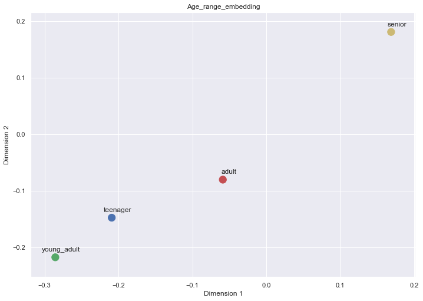

```python
Age_range_int_embed = []
Age_range_weight = model.get_layer("Age_int_embed").get_weights()[0]

np.set_printoptions(suppress=True) # stop using scientific notation

age_range = encoders["Age"].classes_

# extract the x and y
x_list = Age_range_weight[:,0]
y_list = Age_range_weight[:,1]

index = 0

for x,y in zip(x_list, y_list):
    ar = age_range[index]
    plt.annotate(ar,# the label
                 xy=(x,y), # data
                 textcoords='offset points', # position of text
                 xytext=(10,10), # position offset of text
                ha='center')
    index += 1

c_value = ['r','y','b','g']
plt.scatter(x_list, y_list, s=150, c=c_value)
plt.xlabel('Dimension 1')
plt.ylabel('Dimension 2')
plt.title('Age_range_embedding')
plt.show()
```

In this graph, we visualize different age range, including teenager, young adult, adult and senior. Since the weights here is 2-dimension originally, so we didn't do t-sne dimensionality reduction to it. As we can see, we find a cluster 'teenager' and 'young adult', which means the model learns that 'teenager' and 'young adult' are similar with each other.  
And from above we can also see 'senior' is away from the other three age range and 'adult' is away from 'tennager' and 'young adult', which means 'senior' is comparatively easier to distinguish itself from other three and 'adult' is easier to distinguish itself from 'teenager' and 'young adult'.

```
[t-SNE] Computing 10 nearest neighbors...
[t-SNE] Indexed 11 samples in 0.000s...
[t-SNE] Computed neighbors for 11 samples in 0.001s...
[t-SNE] Computed conditional probabilities for sample 11 / 11
[t-SNE] Mean sigma: 1125899906842624.000000
[t-SNE] KL divergence after 250 iterations with early exaggeration: 50.427929
[t-SNE] KL divergence after 500 iterations: 0.268226
```

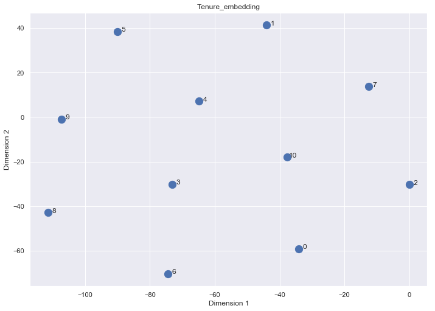

```python
from sklearn.manifold import TSNE

Tenure_int_embed = []
Tenure_int_embed = model.get_layer("Tenure_int_embed").get_weights()[0]

tsne = TSNE(n_components=2, verbose=1, perplexity=30, n_iter=500)
tsne_result = tsne.fit_transform(Tenure_int_embed)
np.set_printoptions(suppress=True)

tenure = encoders["Tenure"].classes_

x_list = tsne_result[:,0]
y_list = tsne_result[:,1]

index = 0

for x,y in zip(x_list, y_list):
    tn = tenure[index]
    plt.annotate(tn,# the label
                 xy=(x,y), # data
                 textcoords='offset points', # position of text
                 xytext=(10,0), # position offset of text
                ha='center')
    index += 1

# c_value = ['r','y','b','g']
plt.scatter(x_list, y_list, s=150)
plt.xlabel('Dimension 1')
plt.ylabel('Dimension 2')
plt.title('Tenure_embedding')
plt.show()
```

Since the Tenure embedding weights is 3-dimensions, we did t-sne dimensionality reduction and made it to 2 dimensions. From the graph above, there is no cluster, all 11 different Tenure classes can be evenly distributed.

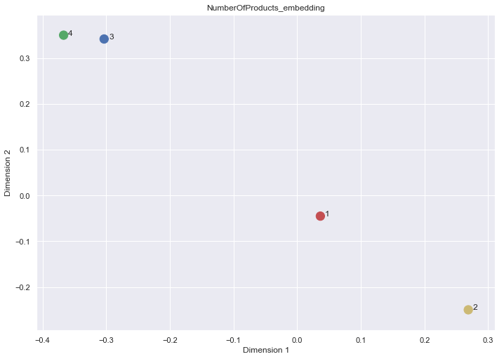

```python
NumOfProducts_int_embed = []
NumOfProducts_int_embed = model.get_layer("NumOfProducts_int_embed").get_weights()[0]

# tsne = TSNE(n_components=2, verbose=1, perplexity=30, n_iter=500)
# tsne_result = tsne.fit_transform(NumOfProducts_int_embed)
np.set_printoptions(suppress=True)

numberofproducts = encoders["NumOfProducts"].classes_

x_list = NumOfProducts_int_embed[:,0]
y_list = NumOfProducts_int_embed[:,1]

index = 0

for x,y in zip(x_list, y_list):
    nop = numberofproducts[index]
    plt.annotate(nop,# the label
                 xy=(x,y), # data
                 textcoords='offset points', # position of text
                 xytext=(10,0), # position offset of text
                ha='center')
    index += 1

c_value = ['r','y','b','g']
plt.scatter(x_list, y_list, s=150, c=c_value)
plt.xlabel('Dimension 1')
plt.ylabel('Dimension 2')
plt.title('NumberOfProducts_embedding')
plt.show()
```

Since the NumberOfProduct embedding weights is also 2-dimension, we skip the t-sne process. Based on the plot result, we find a cluster '3' and '4', which means the model learns that people who have 3 or 4 products are similar with each other.  
We can also see '2' is away from the other three and '1' is away from '3' and '4', which means '2' is comparatively easier to distinguish itself from other three and '1' is easier to distinguish itself from '3' and '4' which also means that people who have 1 or 2 products are easier to be classified.